# DS 202 Final Project

John Barmen, Braedon Giblin, Yufei Huang, Emma Smykalski, Kerstin Swanson

## Introduction/Background:

Our group wanted to take an in-depth look at American work-life balance. There are many facets to explore, such as how sex, job type, marital status, location, age, and number of dependents play a role in work-life balance, and how this has changed over time.

We collected our data from the IPUMS database, which has a collection of American Census data as well as American Community Surveys. The Census records span from 1790-2010, and the American Community Surveys span from 2000-present. The IPUMS database provides free access to social and economic data, and there is a massive collection of observations, with a wide array of variables.

## Data Collection:

We used IPUMS database, selecting a subset of variables and then selected a sample of 15,000 households per census/survey. We narrowed our scope to be from 1980-now, to get a better look at the most recent changes in work-life balance. Subsetting our dataframe was necessary in order to shrink the database to a reasonable size that would fit on github and allow us to perform analysis in a timely fashion.

## Questions

### How does gender play a role in work/life balance?

Analysis:

```r
tbl <- data %>%
  filter(EMPSTAT == 1) %>%
   mutate(Sex = if_else(SEX==1, "Male", "Female")) %>%
  group_by(Sex) %>%
  summarise("Average Hours per Week" = mean(UHRSWORK), "Average Travel Time" = mean(TRANTIME))
formattable(tbl)
```

| Sex | Average Hours per Week | Average Travel Time |
| --- | --- | --- |
| Female | 36.18447 | 21.15519 |
| Male | 42.05617 | 24.62921 |

To calculate average workweeks and commutes, we first removed all people of unemployed work status, so we would not be diluting our numbers with zeroes for hours worked per week and commute time. We can see that overall, on average men work more per week than women, with an average of about 42 hours per week as opposed to 36 hours per week. We can also see that men have slightly longer commutes, averaging about 25 minutes versus women’s average commutes of 21 minutes.

### How has workweek and commute changed over time?

Analysis:

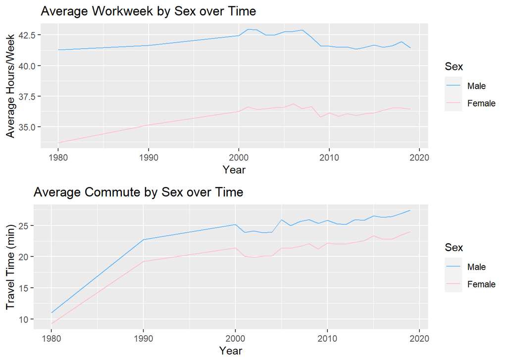

```r
p_hours <- data %>%
  filter(EMPSTAT == 1) %>%
  group_by(YEAR, SEX) %>%
  summarise("Average Hours per Week" = mean(UHRSWORK), "Average Travel Time" = mean(TRANTIME)) %>%
  ggplot(aes(x=YEAR, y=`Average Hours per Week`, color= as.factor(SEX))) + geom_line() + labs(title = "Average Workweek by Sex over Time", x = "Year", y= "Average Hours/Week") +
  scale_color_manual(name="Sex", labels = c("Male","Female"), values=c('steelblue1','Pink'))

p_travel <- data %>%
  filter(EMPSTAT == 1) %>%
  group_by(YEAR, SEX) %>%
  summarise("Average Hours per Week" = mean(UHRSWORK), "Average Travel Time" = mean(TRANTIME)) %>%
  ggplot(aes(x=YEAR, y=`Average Travel Time`, color= as.factor(SEX))) + geom_line() + labs(title = "Average Commute by Sex over Time", x = "Year", y="Travel Time (min)") + scale_color_manual(name="Sex",labels = c("Male", "Female"), values=c('steelblue1','Pink'))

grid.arrange(p_hours, p_travel)
```

Looking at workweek and commute over time based on sex, we can see that between 1980-present, men have always averaged a longer workweek and commute. Commute seems to have grown more steadily over time than workweek. There is also a larger gender gap in average hours worked per week than in average commute time. An interesting finding would be that, for both men and women, average workweek decreased after 2008 (the Great Recession), and it has yet to reach the same level it was at before 2008.

### How many hours does the average American work per week? How as that changed over time?

We found that most people worked an average of about 33 hours per week. We examined how this number has changed over the past 40 years, and recognized that there has been a subtle down trend in the amount of hours people work. We noted this especially after the Great Recession, when many people lost their jobs or had hours reduced. The most any respondant worked in an average week was 99 hours.

Descriptive statistics of peoples 2019 Work habits:

```r
data %>%
  filter(CLASSWKR > 0 & YEAR == 2019) %>%
  select(UHRSWORK) %>%
  summary() %>%
  tibble() %>%
  formattable()
```

| . |
| --- |
| Min. : 0.0 |
| 1st Qu.:24.0 |
| Median :40.0 |
| Mean :33.5 |
| 3rd Qu.:40.0 |
| Max. :99.0 |

Average work hours by year:

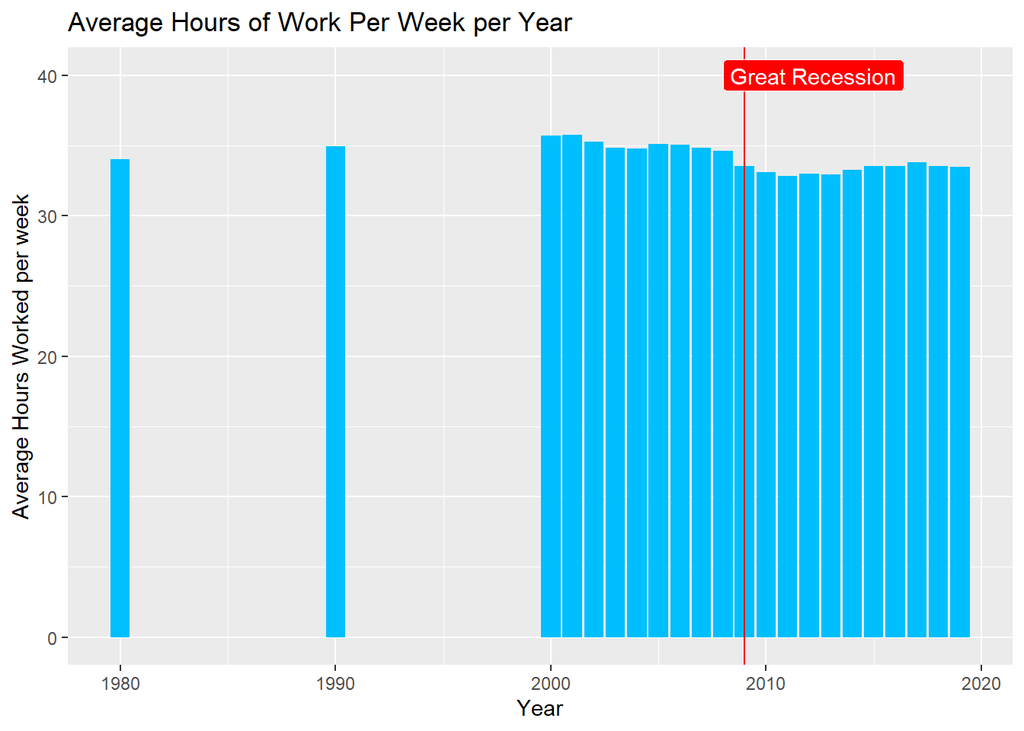

```r
data %>%
  filter(CLASSWKR > 0) %>%
  group_by(YEAR) %>%
  summarise(UHRSWORK = mean(UHRSWORK)) %>%
  ggplot(aes(x=YEAR, y=UHRSWORK)) + geom_bar(fill = "deepskyblue", stat="identity") +
  labs(x="Year", y= "Average Hours Worked per week", title="Average Hours of Work Per Week per Year") +
  geom_vline(xintercept=2009, color="red") +
  annotate("label", x=2008, y=40, label="Great Recession", hjust=0, fill="red", color="white")
```

Overall, hours worked per week has remained fairly static, and only has subtly decreased over the past 40 years.

### What types of jobs typically require longer commutes and longer work weeks?

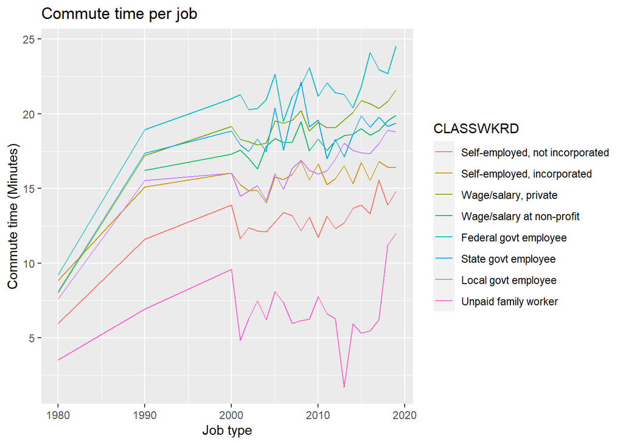

```r
data %>%
  filter(CLASSWKR > 0) %>%
  mutate(CLASSWKRD = as_factor(CLASSWKRD)) %>%
  group_by(YEAR, CLASSWKRD) %>%
  summarise(TRANTIME = mean(TRANTIME)) %>%
  ungroup() %>%
  ggplot(aes(x=YEAR, y=TRANTIME, group=CLASSWKRD, color=CLASSWKRD)) + geom_line() +
  labs(x="Job type", y= "Commute time (Minutes)", title="Commute time per job", fill="Job type")
```

Similarly we have noticed a general decrease in hours worked across most job types. Notably, however, there was not a significant increase in hours worked for governement employees.

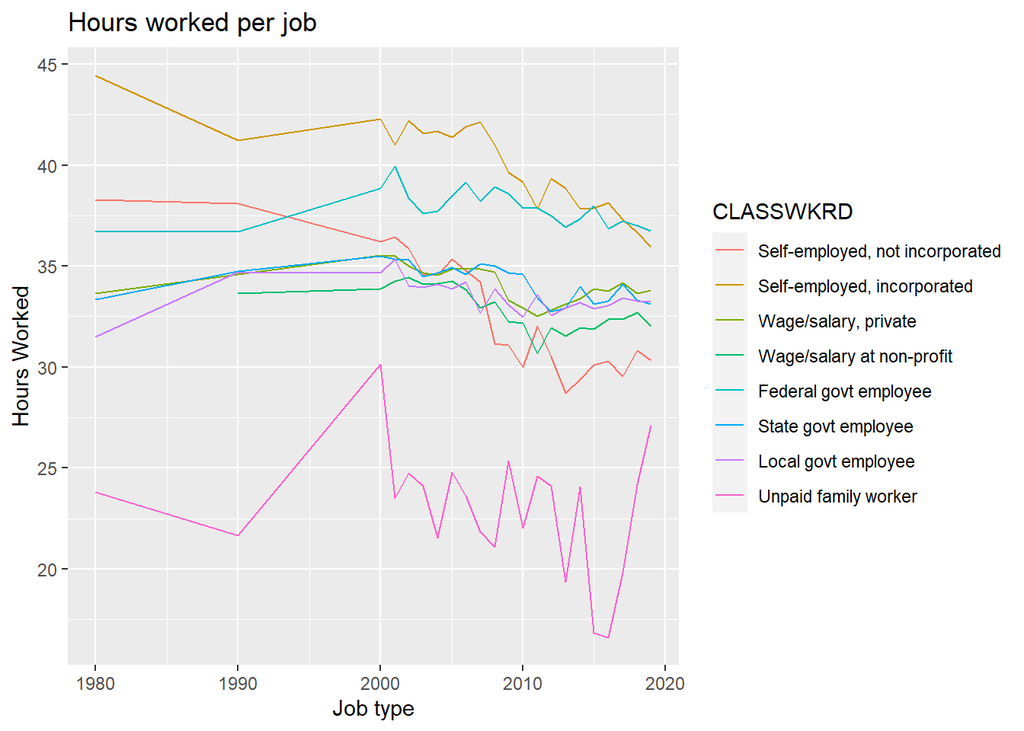

```r
data %>%
  filter(CLASSWKR > 0) %>%
  mutate(CLASSWKRD = as_factor(CLASSWKRD)) %>%
  group_by(YEAR, CLASSWKRD) %>%
  summarise(UHRSWORK = mean(UHRSWORK),
            n = mean(n)) %>%
  ungroup() %>%
  ggplot(aes(x=YEAR, y=UHRSWORK, group=CLASSWKRD, color=CLASSWKRD)) + geom_line() +
  labs(x="Job type", y= "Hours Worked", title="Hours worked per job", fill="Job type")
```

### How does the American work life balance change in regards to income, marriage rates, and kids or dependents?

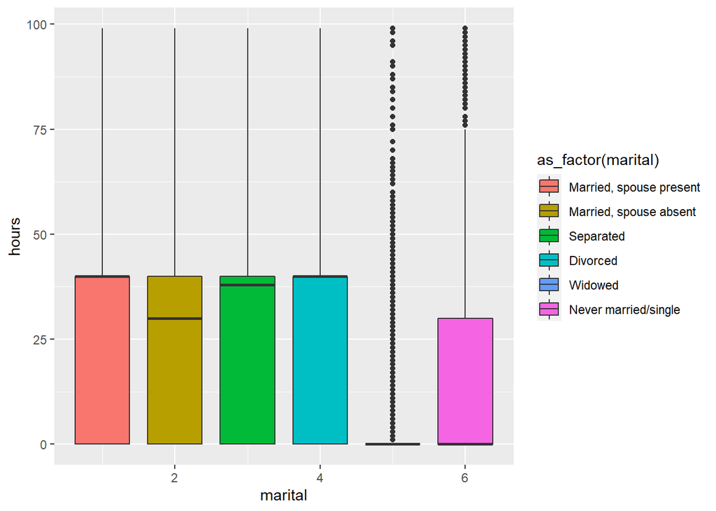

```r
data2 <- data %>%
  select(UHRSWORK, NCHILD, INCTOT, FTOTINC,MARST, YEAR, TRANTIME) %>%
  rename(hours = UHRSWORK,
         dependents = NCHILD,
         incomesolo = INCTOT,
         incomefamily = FTOTINC,
         marital = MARST,
         year = YEAR,
         traintime = TRANTIME)
data2 <- na.omit(data2)
data2$married <- ifelse(data2$marital<=2, 1, 0) # 1 married, 0 not married
ggplot(data2, aes(y = hours, x = marital, fill=as_factor(marital)))+geom_boxplot()
```

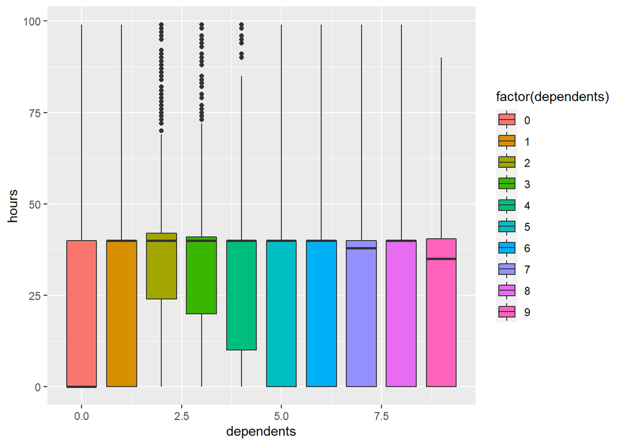

```r
ggplot(data2, aes(y = hours, x = dependents, fill=factor(dependents)))+geom_boxplot()
```

When we built the data set we initially tried to ad variables we thought would be important to determining work life balance, measured in hours worked per week. These included variables like marital status, family income, family size in regards to dependents, as well as other variables we thought may have been useful predictors. The two plots I choose to explain this problem are above. These two plots are things that we thought would be very influential variables to determine work life balance. However, the plots were less explanitory then previously predicted. They do a good job showing how little difference can be created as variables are changed. In the end we ended up finding that although the predictors we picked are valuable we discovered that they are not as valuable as we thought. There are probably many reliant predictors that we did not have access to that would have been more valuable but that is outside the scope of this analysis.

### What variables in our data set are significantly changed overtime when we predict family income?

1. divide data into 4 different time lines

   ```r
   year80s = data %>%
     filter(YEAR == c(1980,1981,1982,1983,1984,1985,1986,1987,1988,1989))

   year90s = data %>%
     filter(YEAR == c(1990,1991,1992,1993,1994,1995,1996,1997,1998,1999))

   year00s = data %>%
     filter(YEAR == c(2000,2001,2002,2003,2004,2005,2006,2007,2008,2009))

   year10s = data %>%
     filter(YEAR == c(2010,2011,2012,2013,2014,2015,2016,2017,2018,2019))
   ```

2. Hypothesis test for selected variables.

   Analysis:

   ```r
   income.fit80 = lm(FTOTINC~SEX+AGE+MARST+EMPSTAT+CLASSWKR+UHRSWORK+PWSTATE2+PWCITY+TRANWORK+TRANTIME, data = year80s)
   summary(income.fit80)
   ```

   ```
   ##
   ## Call:
   ## lm(formula = FTOTINC ~ SEX + AGE + MARST + EMPSTAT + CLASSWKR +
   ##     UHRSWORK + PWSTATE2 + PWCITY + TRANWORK + TRANTIME, data = year80s)
   ##
   ## Residuals:
   ##      Min       1Q   Median       3Q      Max
   ## -1592099  -471717   -67391    87405 10058726
   ##
   ## Coefficients:
   ##               Estimate Std. Error t value Pr(>|t|)
   ## (Intercept) -8.086e+05  1.286e+05  -6.285 3.67e-10 ***
   ## SEX         -1.444e+05  5.195e+04  -2.780  0.00547 **
   ## AGE         -2.540e+03  1.684e+03  -1.508  0.13155
   ## MARST        1.756e+05  1.373e+04  12.795  < 2e-16 ***
   ## EMPSTAT      3.900e+05  3.126e+04  12.475  < 2e-16 ***
   ## CLASSWKR     1.160e+05  4.222e+04   2.748  0.00602 **
   ## UHRSWORK     3.459e+03  2.027e+03   1.707  0.08796 .
   ## PWSTATE2     5.946e+02  1.776e+03   0.335  0.73778
   ## PWCITY      -9.519e+00  2.788e+01  -0.341  0.73276
   ## TRANWORK     8.932e+03  2.256e+03   3.959 7.66e-05 ***
   ## TRANTIME    -5.153e+03  2.691e+03  -1.915  0.05554 .
   ## ---
   ## Signif. codes:  0 '***' 0.001 '**' 0.01 '*' 0.05 '.' 0.1 ' ' 1
   ##
   ## Residual standard error: 1502000 on 3628 degrees of freedom
   ## Multiple R-squared:  0.08287,    Adjusted R-squared:  0.08034
   ## F-statistic: 32.78 on 10 and 3628 DF,  p-value: < 2.2e-16
   ```

   ```r
   income.fit90 = lm(FTOTINC~SEX+AGE+MARST+EMPSTAT+CLASSWKR+UHRSWORK+PWSTATE2+PWCITY+TRANWORK+TRANTIME, data = year90s)
   summary(income.fit90)
   ```

   ```
   ##
   ## Call:
   ## lm(formula = FTOTINC ~ SEX + AGE + MARST + EMPSTAT + CLASSWKR +
   ##     UHRSWORK + PWSTATE2 + PWCITY + TRANWORK + TRANTIME, data = year90s)
   ##
   ## Residuals:
   ##     Min      1Q  Median      3Q     Max
   ## -966032 -322665 -113061    7216 9917165
   ##
   ## Coefficients:
   ##               Estimate Std. Error t value Pr(>|t|)
   ## (Intercept) -301196.29  111494.16  -2.701 0.006938 **
   ## SEX          -80824.44   45442.46  -1.779 0.075393 .
   ## AGE           -1703.03    1519.12  -1.121 0.262341
   ## MARST         93501.11   11962.82   7.816 7.22e-15 ***
   ## EMPSTAT      185978.17   31113.18   5.977 2.50e-09 ***
   ## CLASSWKR      77537.82   37950.19   2.043 0.041115 *
   ## UHRSWORK        786.31    1699.60   0.463 0.643650
   ## PWSTATE2        725.11    1778.91   0.408 0.683581
   ## PWCITY          -30.61      17.52  -1.747 0.080681 .
   ## TRANWORK       6401.28    1922.35   3.330 0.000878 ***
   ## TRANTIME      -3233.79    1772.60  -1.824 0.068192 .
   ## ---
   ## Signif. codes:  0 '***' 0.001 '**' 0.01 '*' 0.05 '.' 0.1 ' ' 1
   ##
   ## Residual standard error: 1281000 on 3385 degrees of freedom
   ## Multiple R-squared:  0.03478,    Adjusted R-squared:  0.03193
   ## F-statistic:  12.2 on 10 and 3385 DF,  p-value: < 2.2e-16
   ```

   ```r
   income.fit00 = lm(FTOTINC~SEX+AGE+MARST+EMPSTAT+CLASSWKR+UHRSWORK+PWSTATE2+PWCITY+TRANWORK+TRANTIME, data = year00s)
   summary(income.fit00)
   ```

   ```
   ##
   ## Call:
   ## lm(formula = FTOTINC ~ SEX + AGE + MARST + EMPSTAT + CLASSWKR +
   ##     UHRSWORK + PWSTATE2 + PWCITY + TRANWORK + TRANTIME, data = year00s)
   ##
   ## Residuals:
   ##      Min       1Q   Median       3Q      Max
   ## -1197726  -434294  -159381    42711 10177919
   ##
   ## Coefficients:
   ##               Estimate Std. Error t value Pr(>|t|)
   ## (Intercept) -1.478e+05  5.356e+04  -2.759  0.00580 **
   ## SEX         -1.565e+05  2.121e+04  -7.376 1.69e-13 ***
   ## AGE         -3.422e+03  7.018e+02  -4.875 1.09e-06 ***
   ## MARST        8.882e+04  5.797e+03  15.320  < 2e-16 ***
   ## EMPSTAT      3.102e+05  1.420e+04  21.851  < 2e-16 ***
   ## CLASSWKR     5.149e+04  1.783e+04   2.887  0.00389 **
   ## UHRSWORK    -2.139e+02  8.639e+02  -0.248  0.80444
   ## PWSTATE2    -8.779e+02  8.574e+02  -1.024  0.30593
   ## PWCITY      -1.596e+01  9.151e+00  -1.744  0.08121 .
   ## TRANWORK     5.988e+03  8.636e+02   6.933 4.24e-12 ***
   ## TRANTIME    -9.077e+02  6.315e+02  -1.437  0.15066
   ## ---
   ## Signif. codes:  0 '***' 0.001 '**' 0.01 '*' 0.05 '.' 0.1 ' ' 1
   ##
   ## Residual standard error: 1473000 on 20009 degrees of freedom
   ##   (17444 observations deleted due to missingness)
   ## Multiple R-squared:  0.04595,    Adjusted R-squared:  0.04547
   ## F-statistic: 96.36 on 10 and 20009 DF,  p-value: < 2.2e-16
   ```

   ```r
   income.fit10 = lm(FTOTINC~SEX+AGE+MARST+EMPSTAT+CLASSWKR+UHRSWORK+PWSTATE2+PWCITY+TRANWORK+TRANTIME, data = year10s)
   summary(income.fit10)
   ```

   ```
   ##
   ## Call:
   ## lm(formula = FTOTINC ~ SEX + AGE + MARST + EMPSTAT + CLASSWKR +
   ##     UHRSWORK + PWSTATE2 + PWCITY + TRANWORK + TRANTIME, data = year10s)
   ##
   ## Residuals:
   ##      Min       1Q   Median       3Q      Max
   ## -1983955  -720169  -233512   106918 10056537
   ##
   ## Coefficients:
   ##               Estimate Std. Error t value Pr(>|t|)
   ## (Intercept) -3.270e+05  1.205e+05  -2.713  0.00669 **
   ## SEX         -2.540e+05  4.761e+04  -5.336 9.82e-08 ***
   ## AGE         -8.301e+03  1.550e+03  -5.355 8.86e-08 ***
   ## MARST        1.491e+05  1.289e+04  11.566  < 2e-16 ***
   ## EMPSTAT      5.623e+05  3.162e+04  17.782  < 2e-16 ***
   ## CLASSWKR     7.362e+03  3.861e+04   0.191  0.84879
   ## UHRSWORK     2.289e+03  2.036e+03   1.124  0.26091
   ## PWSTATE2     4.999e+02  1.951e+03   0.256  0.79777
   ## PWCITY      -6.005e+00  2.047e+01  -0.293  0.76926
   ## TRANWORK     1.466e+04  1.941e+03   7.555 4.77e-14 ***
   ## TRANTIME    -1.319e+03  1.554e+03  -0.849  0.39587
   ## ---
   ## Signif. codes:  0 '***' 0.001 '**' 0.01 '*' 0.05 '.' 0.1 ' ' 1
   ##
   ## Residual standard error: 1882000 on 6404 degrees of freedom
   ##   (25206 observations deleted due to missingness)
   ## Multiple R-squared:  0.08499,    Adjusted R-squared:  0.08356
   ## F-statistic: 59.48 on 10 and 6404 DF,  p-value: < 2.2e-16
   ```

3. Final graph over time

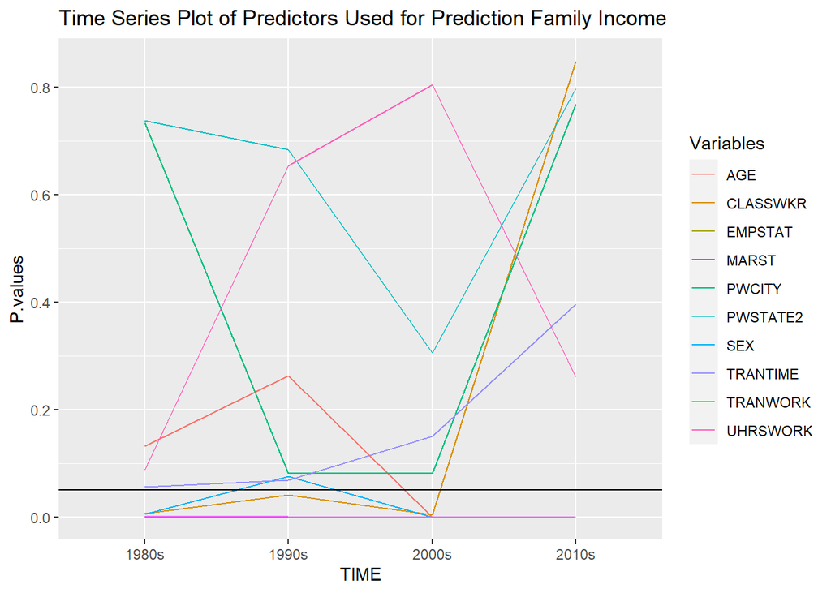

   ```r
   frame = data.frame("Variables" = c("SEX","SEX","SEX","SEX","AGE","AGE","AGE","AGE","MARST","MARST","MARST","MARST","EMPSTAT","EMPSTAT","EMPSTAT","EMPSTAT","CLASSWKR","CLASSWKR","CLASSWKR","CLASSWKR","UHRSWORK","UHRSWORK","UHRSWORK","UHRSWORK","PWSTATE2","PWSTATE2","PWSTATE2","PWSTATE2","PWCITY","PWCITY","PWCITY","PWCITY","TRANWORK","TRANWORK","TRANWORK","TRANWORK","TRANTIME","TRANTIME","TRANTIME","TRANTIME"),
                      "TIME" = c("1980s","1990s","2000s","2010s","1980s","1990s","2000s","2010s","1980s","1990s","2000s","2010s","1980s","1990s","2000s","2010s","1980s","1990s","2000s","2010s","1980s","1990s","2000s","2010s","1980s","1990s","2000s","2010s","1980s","1990s","2000s","2010s","1980s","1990s","2000s","2010s","1980s","1990s","2000s","2010s"),
                      "P-values" = c(0.00547,0.075393,0.000000000000169,0.0000000982,0.13155,0.262341,0.00000109,0.0000000886,0.0000000000000002,0.00000000000000722,0.0000000000000002,0.0000000000000002,0.0000000000000002,0.0000000025,0.0000000000000002,0.0000000000000002,0.00602,0.041115,0.00389,0.84879,0.08796,0.653650,0.80444,0.26091,0.73778,0.683581,0.30593,0.79777,0.73276,0.080681,0.08121,0.76926,0.0000766,0.000878,0.00000000000424,0.0000000000000477,0.05554,0.068192,0.15066,0.39587))

   frame$Variables = as.character(frame$Variables)
   frame$TIME = as.factor(frame$TIME)
   frame$P.values = as.numeric(frame$P.values)

   ggplot(frame, aes(x=TIME, y=P.values, group=Variables, color=Variables))+geom_line()+ggtitle("Time Series Plot of Predictors Used for Prediction Family Income")+geom_abline(slope=0,intercept = 0.05)
   ```

### Are there any changes in the economic center cities and their proportion? Is this related to the changes in their life and work balance?

Trying to figure out if there exist any cities that would be a potential economic center city

```r
table(year80s$PWCITY)
```

```
##
##    0   10   70   90  350  450  510  530  590  670  770  810 1090 1190 1290 1330
## 3459    1    1    1    3    1    1    6    1    1    2    4    1   12    2    2
## 1410 1450 1710 2050 2090 2130 2350 2470 2570 2650 2710 2870 2890 3030 3150 3260
##    1    4    3    1    1    1    2    1    1    1    1    2    3    1    1    3
## 3490 3650 3690 3730 3750 3870 4010 4110 4130 4150 4170 4570 4610 4630 4810 4930
##    1    1    1   10    4    1    1    3    4    2    2    2   19    1    1    4
## 4990 5070 5130 5210 5330 5350 5530 5650 5750 5870 6090 6110 6130 6210 6230 6250
##    2    1    2    1    4    2    3    1    1    2    3    2    2    1    2    1
## 6270 6290 6310 6430 6590 6630 6850 6970 7050 7070 7230 7530 7570
##    4    4    1    2    1    2    3    1    1    3    3    1    1
```

```r
table(year90s$PWCITY)
```

```
##
##    0   50   90  210  290  310  450  490  510  530  590  670  810  890 1150 1190
## 3081    2    1    1    2    1    1    3    3    2    2    2    7    1    1   15
## 1330 1390 1710 1750 1990 2050 2110 2130 2290 2330 2350 2370 2430 2470 2490 2530
##    3    3    6    6    1    1    1    2    2    2    1    4    1    1    1    2
## 2570 2650 2770 2830 3010 3030 3090 3150 3330 3410 3470 3670 3690 3730 3750 3770
##    1    1    1    2    1    3    2    1    4    2    1    1    1   29    2    1
## 4010 4150 4170 4530 4570 4610 4630 4750 4810 4950 4990 5070 5170 5270 5330 5450
##    2    7    1    1    5   40    1    1    2   14    1    1    1    2    8    1
## 5530 5650 5870 5930 5970 6030 6090 6110 6170 6190 6230 6270 6290 6330 6430 6490
##    3    2    2    4    2    4    7    3    1    1    7   15    7    3    4    3
## 6630 6670 6730 6750 6890 7070 7230 7530
##    2    1    1    1    3    3   13    1
```

```r
table(year00s$PWCITY)
```

```
##
##     0    10    90   130   210   270   510   530   590   670   680   800   810
## 18650     3     4     4     5     6    11    24    11     5     4    10    25
##   830   880   890   930  1000  1090  1110  1150  1190  1290  1410  1450  1500
##     5     5     7     1     4    22     6     9    67    19    16     9     7
##  1520  1670  1730  1750  1800  1990  2050  2090  2170  2240  2260  2270  2300
##    13     3     8     9     1     3     2     1     2     5     7     1     4
##  2330  2370  2470  2530  2550  2570  2650  2710  2950  3010  3020  3090  3150
##     4    12     4     4     3     8     6     9     3     2    10     8     3
##  3260  3330  3390  3470  3590  3650  3670  3690  3770  3870  3910  3960  4010
##    23     5     3     4    10     7     6    10     2    13     3     3    22
##  4130  4150  4170  4190  4250  4270  4530  4570  4610  4630  4750  4810  4860
##    14    18    10     3     9     3     6     6   230     7    11    11     1
##  4990  5030  5130  5170  5210  5270  5330  5370  5650  5750  5770  5810  5870
##    12     7     3     4     3     6    32    17     4    16     7    10     7
##  5890  5930  5970  6030  6090  6110  6190  6250  6290  6370  6430  6500  6530
##    14    13     6    17    15    11     2    11    38     7    38     2     3
##  6590  6630  6650  6670  6690  6730  6750  6790  6850  6870  6960  6970  7000
##     5     4     8     7     6     8     4     3     7     8     6     7     7
##  7070  7100  7130  7180  7230  7250  7320  7410  7530  7570  7590
##    11    10    13     5    43     2     3    17     8     5     4
```

```r
table(year10s$PWCITY)
```

```
##
##    0   10   90  210  270  510  530  590  670  680  800  810  830  880  890  930
## 5951    1    2    2    2    4    5    4    1    3    1   16    1    1    2    4
## 1090 1110 1190 1290 1410 1500 1520 1670 1730 1750 1990 2090 2170 2240 2260 2300
##    7    1   26    8    5    2    2    1    2    7    1    2    2    1    1    2
## 2330 2370 2470 2530 2550 2570 2650 2710 2950 2970 3010 3020 3090 3150 3260 3330
##    4    4    2    1    1    3    2    2    5    1    1    4    2    1    4    2
## 3390 3470 3590 3650 3670 3690 3770 3870 3910 3960 4010 4130 4150 4170 4190 4250
##    3    2    1    4    1    6    1    3    1    1    8    2    1    3    2    2
## 4270 4530 4570 4610 4630 4750 4810 4860 4990 5030 5170 5270 5330 5370 5450 5650
##    1    1    2   84    3    1    7    2    6    2    1    2    6    1    2    1
## 5750 5770 5810 5870 5890 5930 5970 6030 6090 6110 6190 6250 6290 6340 6370 6430
##    4    1    3    3    2    5    4    9    5    7    5    1   15    1    2   13
## 6590 6630 6650 6670 6690 6790 6850 6870 6960 6970 7000 7070 7130 7230 7410 7530
##    1    4    9    3    2    1    1    2    1    2    3    3    4   18    2    4
## 7570
##    3
```

```r
new80s = year80s%>%
  filter(PWCITY!=0)
##table(new80s$PWCITY)
new80s %>%
  group_by(PWCITY) %>%
  summarize(meanINC =  mean(INCTOT)) %>%
  arrange(desc(meanINC)) %>%
  head(3) %>%
  formattable()
```

| PWCITY | meanINC |
| --- | --- |
| 7050 | 49010.00 |
| 4110 | 36773.33 |
| 5070 | 30810.00 |

```r
new90s = year90s%>%
  filter(PWCITY!=0)
##table(new90s$PWCITY)
new90s %>%
  group_by(PWCITY) %>%
  summarize(meanINC =  mean(INCTOT)) %>%
  arrange(desc(meanINC)) %>%
  head(3) %>%
  formattable()
```

| PWCITY | meanINC |
| --- | --- |
| 6730 | 228743 |
| 6630 | 81030 |
| 5970 | 73000 |

```r
new00s = year00s%>%
  filter(PWCITY!=0)
##table(new00s$PWCITY)
new00s %>%
  group_by(PWCITY) %>%
  summarize(meanINC =  mean(INCTOT)) %>%
  arrange(desc(meanINC)) %>%
  head(3) %>%
  formattable()
```

| PWCITY | meanINC |
| --- | --- |
| 6870 | 127110.0 |
| 6730 | 123536.2 |
| 90 | 98750.0 |

```r
new10s = year10s%>%
  filter(PWCITY!=0)
##table(new10s$PWCITY)
new10s %>%
  group_by(PWCITY) %>%
  summarize(meanINC =  mean(INCTOT)) %>%
  arrange(desc(meanINC)) %>%
  head(3) %>%
  formattable()
```

| PWCITY | meanINC |
| --- | --- |
| 2300 | 228100.0 |
| 6290 | 109282.7 |
| 810 | 106425.0 |

After finding the city codes and comparing with the city information from IPUMS, this data does not show a city pattern for us to come up a conclusion for this research question due to the lack of clear information, or missing values for both city and states variables.

### How has the family breadwinner role changed over time?

To see how the average age of the breadwinner has changed over the years, we averaged out the age of all the breadwinners in one year to obtain the average age for that year. We then created a time series plot to express how the age has changed over time. The time series plot below shows that from 1980 to 2019 the average age of the household breadwinner has increased from under 30 years old in 1980 to almost 40 years old in 2019.

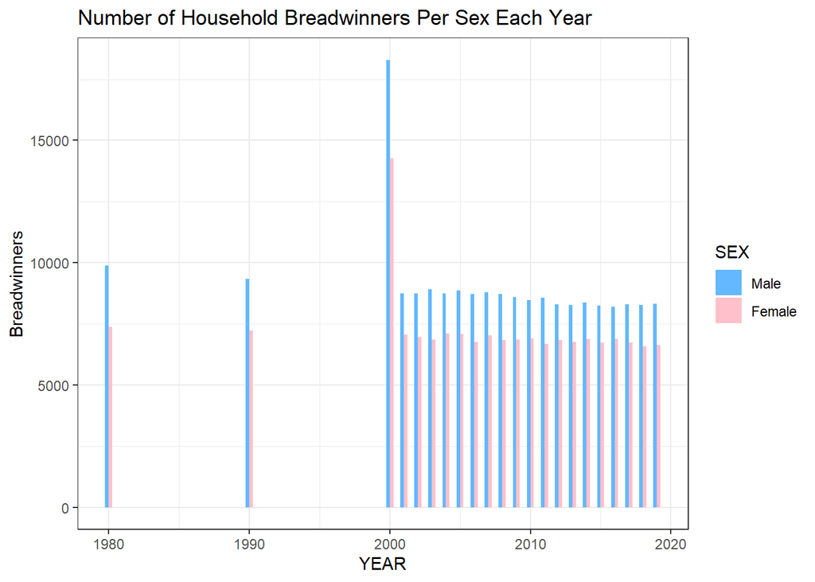

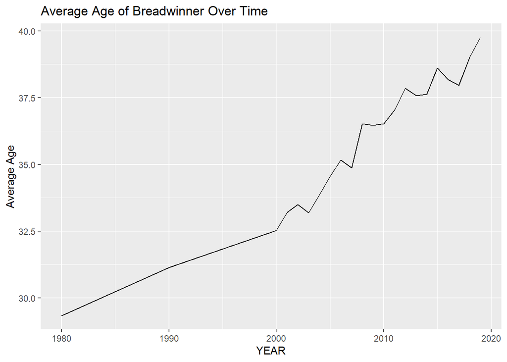

### How does state affect the relationship between work/life balance?

Our next question we explored was how the state of which the respondents job was located in affected the work/life balance. In order to see the relationship between state and work/life balance we took the variable representing the amount of hours spent at work in the last week and added twice the variable indicating how long the respondents commute to work was to get the total time that work took up during the week. We then grouped by state and found the average work time for all the respondents working in those states. Then, we divided by the total hours in a week to see the percent of the week that each state spent for work. By combining this new data frame with the states data frame in the maps library, we could create a map showing the average percent of the week that each state spent on work visually. The map below shows the outcome of that. The darker blue states, indicating that the state had a high average percent of the week spent in work, include California, Illinois, New York, Washington DC, and Georgia with New York and Washington DC being the darkest. The lighter blue states, indicating that the state had a low average percent of the week spent in work, include Montana, North Dakota, South Dakota, Wyoming, and Idaho. These results make sense as the darker blue states have larger cities and the lighter colored states are known for their nature attractions and not as frequent big cities.

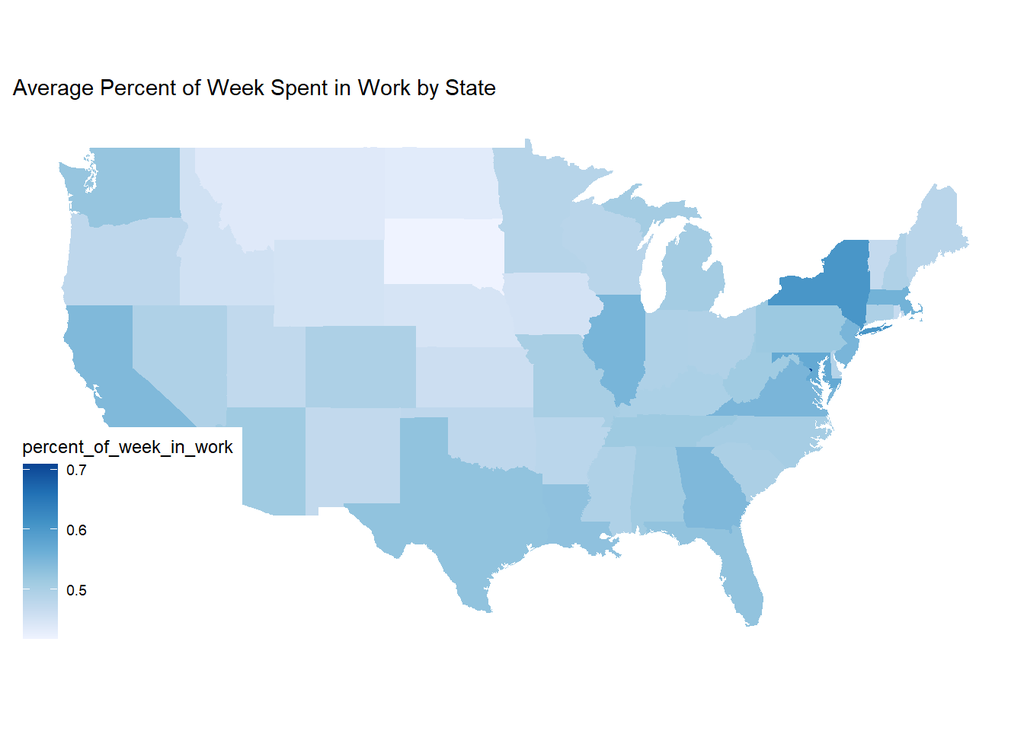

## Contributions

- Kerstin - I searched the IPUMS database for variables related to our research topic, selected samples during our specified time period, and extracted the data into a new file that the team could work with. I looked into and wrote the background information, introduction, and data collection materials for our presentation and this report. I also took on the question “how does gender play a role in work/life balance?”.
- Yufei Huang: I came up two research questions for our project, which are the significant predictors for family income overtime and the potential economic cities. Participaed in the analyzation and summarized my own part conclusion. Finished the PowerPoint, Presentation, and Final Report with my group members.
- Emma Smykalski: I ran the analysis and produced the graphs for how the family breadwinner role has changed over time and how state affects the relationship between work/life balance. For the presentation I recorded the slides that corresponded to that analysis. In our final report, I produced my analysis and graphs and I wrote the paragraphs and about my analysis as well as the conclusion.
- Braedon Giblin: I did all of the analysis for our questions on time spent working per week and work / commute time and job type analysis. I also took charge of managing Git, editing and publishing our video, and assembling and compiling our final report.
- John Barmen: I answered the questions on how American work/life balance changes as a result of several different independent variables. I also examined some commute time data. Finally, I setup and manged our group’s primary communication channel.

## Citations

> Sarah Flood, Miriam King, Renae Rodgers, Steven Ruggles and J. Robert Warren. Integrated Public Use Microdata Series, Current Population Survey: Version 8.0 [dataset]. Minneapolis, MN: IPUMS, 2020. https://doi.org/10.18128/D030.V8.